# Night study - Bayes analysis

# 1 Introduction

This report describes the analysis and results of data collected in a sleep study. Participants completed questionnaires in the evening and sleep dairies in the morning for 16 nights. After a one-week baseline, participants listened to one of two music playlists or silence as they went to sleep for three nights each. The order of the three conditions (Music A, Music B, Silence) was randomised for each participant.

We have three dependent measures of interest extracted from the sleep diary entries:

Sleep quality (SQ, rated on five levels from very poor to very good) Sleep onset latency (SOL, in minutes) Sleep efficiency (SE, the percentage of time asleep out of the total time spent in bed at night)

We also have three mood-related covariates from ratings completed each evening before the participant went to sleep:

Valence (negative to positive) Tension (tense to relaxed) Alertness (measured on the Karolisnka Sleepiness Scale)

In a follow up survey participants also indicated how likely they would choose each of the two playlists to go to sleep. This gave us an indication of which was the more preferred of the two playlists for each participant.

The aim of this analysis is to compare the average effect of each condition on each sleep measure, accounting for interactions from the mood covariates. We also want to compare the effect of the music condition if it is the preferred playlist or not.

## 1.1 Set up

```r
# Load libraries.
library(tidyverse)
library(GGally)
library(ggpubr)
library(reshape2)
library(brms)
library(marginaleffects)
library(ggdist)
```

```r
library(cowplot)
# Set wd
# setwd()

# Import data.
data_sleep <- read.csv('data_sleep.csv')
```

## 1.2 Preliminary checks

We’ll first take a look at the distributions of the variables, and create a scatterplot matrix to look at correlations between them.

### 1.2.1 Data distributions

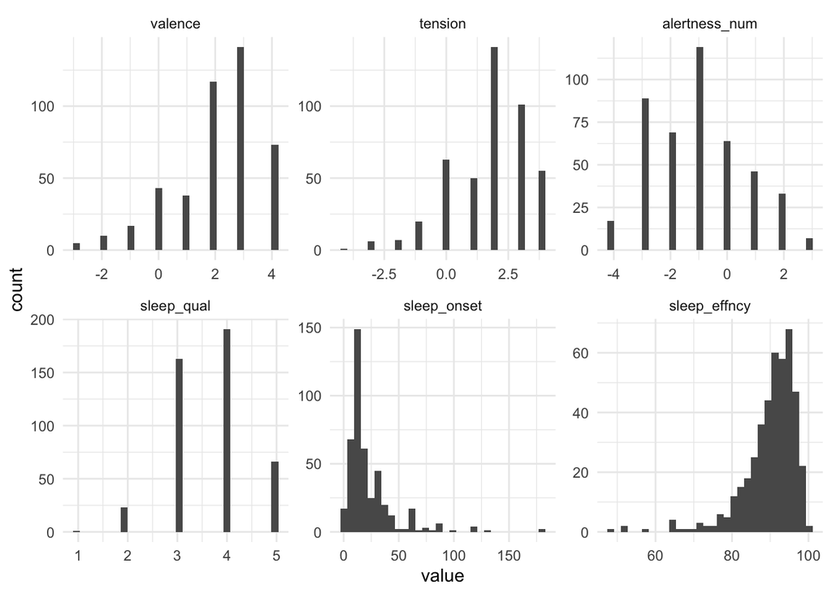

```r
ggplot(melt(data_sleep[,c(5:7,28,9,10,15)], id = 'cndtn'), aes(value)) +
  geom_histogram() +
  facet_wrap(~variable, scales = 'free') +
  theme_minimal()
```

### 1.2.2 Correlations

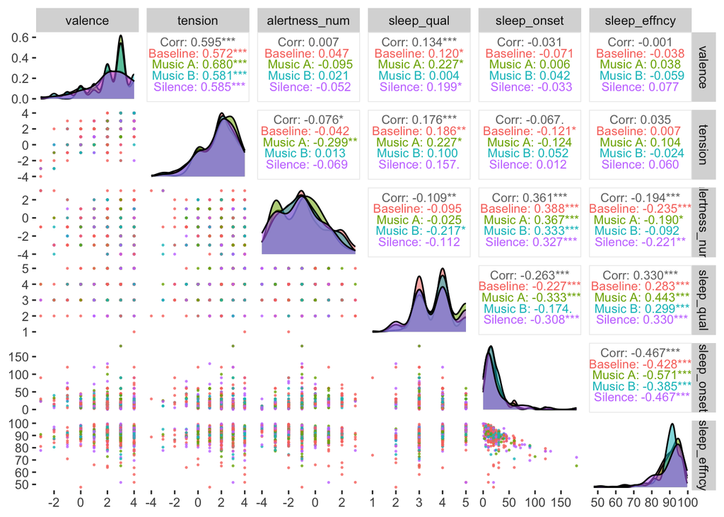

```r
# Scatter plot matrix using numerical versions of each variable.
ggpairs(data_sleep, columns = c(6,7,28,9,10,15), aes(colour = cndtn, alpha = 0.7),
                    upper = list(continuous = wrap(ggally_cor, method = "kendall", size = 3)),
                    lower = list(continuous = wrap("points", alpha = 0.7, size = 0.3)),
                    progress = FALSE) +
  theme(panel.background = element_blank())
```

NAs causing errors.

The scatterplot matrix and included correlations analyses indicate associations between the mood at bed time ratings and sleep outcomes, albeit small, supporting the need to incorporate those factors in our analysis.

# 2 Main conditions

## 2.1 SQ

### 2.1.1 Model fit

```r
mdl_sq <-
  brm(
    sleep_qual ~
      cndtn * (alertness + tension + valence) +
      (cndtn | ID),
    data = data_sleep,
    family = cumulative(link = "probit"),
    prior = set_prior("normal(0, 1)", class = "b"),
    control = list(adapt_delta = 0.99)
  )
```

```
## Trying to compile a simple C file
```

[output not shown]

Posterior predictions check.

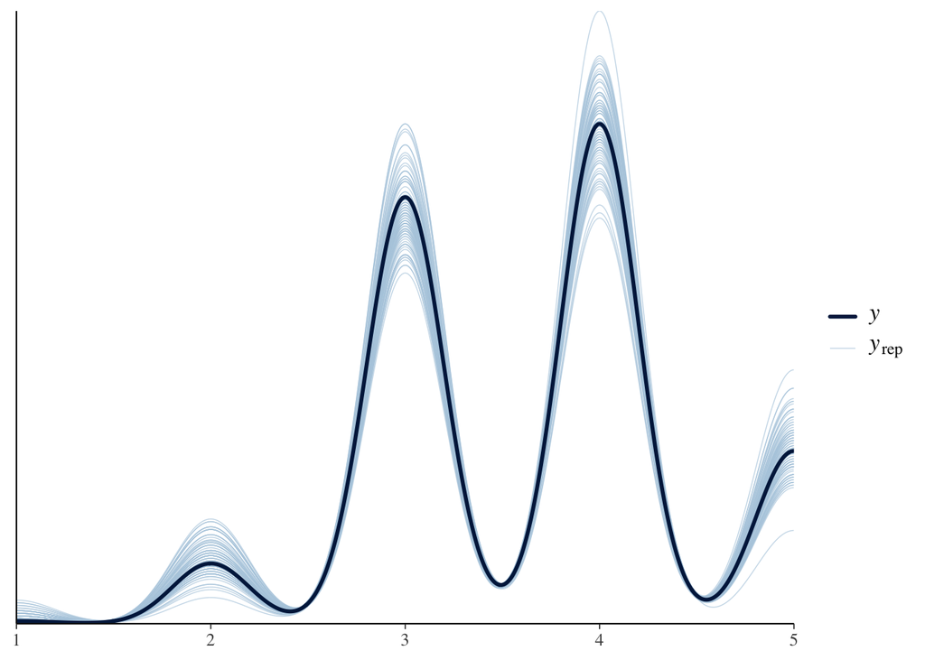

```r
pp_check(mdl_sq, ndraws = 100)
```

### 2.1.2 Average predictions

Extract some effects of interest using marginaleffects and plot the results.

```r
avg_predictions(mdl_sq, by = "cndtn", type = "link")
```

```
##
##     cndtn Estimate 2.5 % 97.5 %
##  Baseline    0.693 0.189   1.23
##  Music A     1.226 0.642   1.85
##  Music B     0.794 0.209   1.40
##  Silence     0.834 0.234   1.44
##
## Columns: cndtn, estimate, conf.low, conf.high
## Type:  link
```

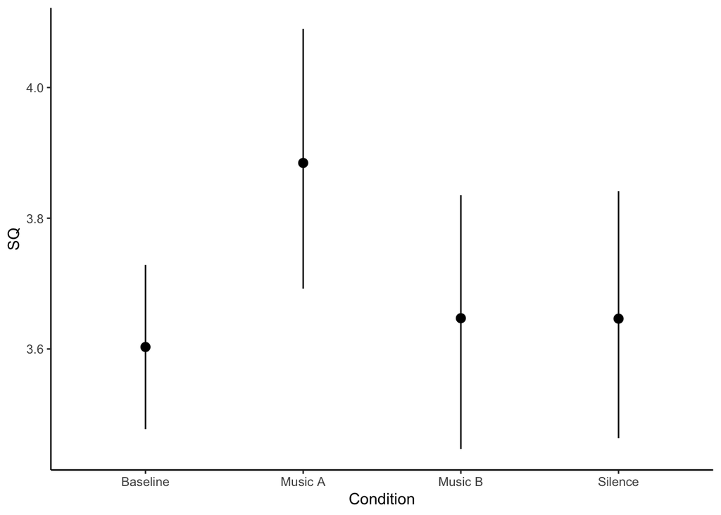

```r
plot_predictions(mdl_sq, by = "cndtn", type = "prediction") +
  labs(x = 'Condition', y = 'SQ') +
  theme_classic()
```

### 2.1.3 Pairwise comparisons

Look at pairwise comparisons.

```r
avg_comparisons(mdl_sq, variables = list(cndtn = "pairwise"), type = "link"
) |>
  print() |>
  posterior_draws(shape = "DxP") |>
  hypothesis(c("b1 > 0",
               "b2 > 0",
               "b3 > 0",
               "b4 < 0",
               "b5 < 0",
               "b6 > 0"))
```

```
##
##   Term                       Contrast Estimate   2.5 % 97.5 %
##  cndtn mean(Music A) - mean(Baseline)  0.42291  0.0874 0.7610
##  cndtn mean(Music B) - mean(Baseline)  0.07257 -0.2137 0.3669
##  cndtn mean(Silence) - mean(Baseline)  0.07643 -0.2187 0.3779
##  cndtn mean(Music B) - mean(Music A)  -0.34372 -0.7306 0.0386
##  cndtn mean(Silence) - mean(Music A)  -0.34382 -0.7327 0.0445
##  cndtn mean(Silence) - mean(Music B)   0.00347 -0.3637 0.3641
##
## Columns: term, contrast, estimate, conf.low, conf.high, predicted_lo, predicted_hi, predicted, tmp_idx
## Type:  link
```

```
## Hypothesis Tests for class :
##   Hypothesis Estimate Est.Error CI.Lower CI.Upper Evid.Ratio Post.Prob Star
## 1   (b1) > 0     0.42      0.17     0.14     0.70     249.00      1.00    *
## 2   (b2) > 0     0.07      0.15    -0.17     0.32       2.16      0.68
## 3   (b3) > 0     0.08      0.15    -0.17     0.33       2.21      0.69
## 4   (b4) < 0    -0.34      0.20    -0.67    -0.02      25.49      0.96    *
## 5   (b5) < 0    -0.34      0.20    -0.67    -0.01      23.24      0.96    *
## 6   (b6) > 0     0.00      0.18    -0.30     0.30       1.03      0.51
## ---
## 'CI': 90%-CI for one-sided and 95%-CI for two-sided hypotheses.
## '*': For one-sided hypotheses, the posterior probability exceeds 95%;
## for two-sided hypotheses, the value tested against lies outside the 95%-CI.
## Posterior probabilities of point hypotheses assume equal prior probabilities.
```

## 2.2 SOL

### 2.2.1 Model fit

One of the sleep onset latency values is 0, which is an issue for the distribution prior. To address this, we’ll add a +1 constant to the variable to avoid rejecting any data points, and then build the model.

```r
data_sleep$sleep_onset_add1 <- data_sleep$sleep_onset + 1

mdl_sol_gamma <-
  brm(
    sleep_onset_add1 ~
      cndtn * (alertness + tension + valence) +
      (cndtn | ID),
    data = data_sleep,
    family = "gamma",
    prior = set_prior("normal(0, 1)", class = "b"),
    control = list(adapt_delta = 0.99)
  )
```

```
## Trying to compile a simple C file
```

[output not shown]

Posterior predictions check.

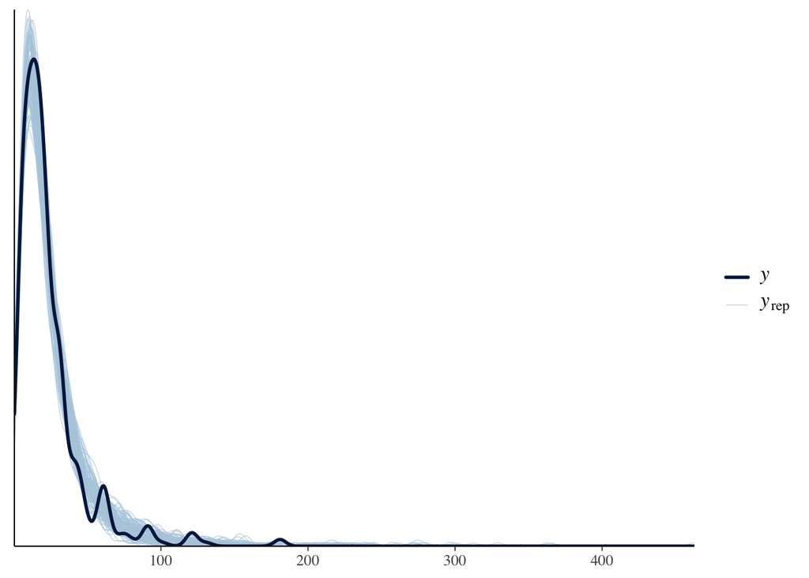

```r
pp_check(mdl_sol_gamma, ndraws = 100)
```

The predictions produce a long tail, but the distribution otherwise looks like a good fit.

### 2.2.2 Average predictions

Extract some effects of interest using marginaleffects and plot results.

```r
avg_predictions(mdl_sol_gamma, by = "cndtn", type = "link")
```

```
##
##     cndtn Estimate 2.5 % 97.5 %
##  Baseline     3.01  2.93   3.08
##  Music A      2.93  2.81   3.06
##  Music B      3.01  2.90   3.13
##  Silence      2.96  2.84   3.08
##
## Columns: cndtn, estimate, conf.low, conf.high
## Type:  link
```

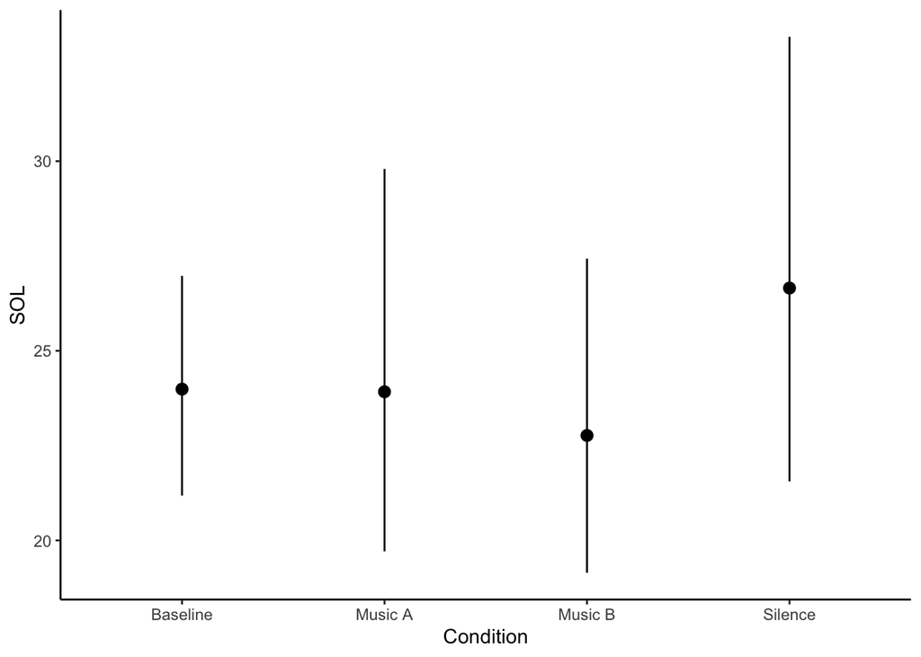

```r
plot_predictions(mdl_sol_gamma, by = "cndtn", type = "prediction") +
  labs(x = 'Condition', y = 'SOL') +
  theme_classic()
```

### 2.2.3 Pairwise comparisons

Look at pairwise comparisons.

```r
avg_comparisons(mdl_sol_gamma, variables = list(cndtn = "pairwise"), type = "link"
) |>
  print() |>
  posterior_draws(shape = "DxP") |>
  hypothesis(c("b1 > 0",
               "b2 > 0",
               "b3 > 0",
               "b4 < 0",
               "b5 < 0",
               "b6 > 0"))
```

```
##
##   Term                       Contrast Estimate  2.5 % 97.5 %
##  cndtn mean(Music A) - mean(Baseline) -0.08019 -0.263  0.104
##  cndtn mean(Music B) - mean(Baseline)  0.00871 -0.136  0.156
##  cndtn mean(Silence) - mean(Baseline)  0.01414 -0.133  0.169
##  cndtn mean(Music B) - mean(Music A)   0.08758 -0.121  0.301
##  cndtn mean(Silence) - mean(Music A)   0.09389 -0.121  0.306
##  cndtn mean(Silence) - mean(Music B)   0.00682 -0.176  0.184
##
## Columns: term, contrast, estimate, conf.low, conf.high, predicted_lo, predicted_hi, predicted, tmp_idx
## Type:  link
```

```
## Hypothesis Tests for class :
##   Hypothesis Estimate Est.Error CI.Lower CI.Upper Evid.Ratio Post.Prob Star
## 1   (b1) > 0    -0.08      0.09    -0.23     0.08       0.25      0.20
## 2   (b2) > 0     0.01      0.07    -0.11     0.13       1.19      0.54
## 3   (b3) > 0     0.01      0.08    -0.11     0.14       1.33      0.57
## 4   (b4) < 0     0.09      0.11    -0.09     0.27       0.27      0.21
## 5   (b5) < 0     0.09      0.11    -0.08     0.27       0.23      0.19
## 6   (b6) > 0     0.01      0.09    -0.14     0.16       1.12      0.53
## ---
## 'CI': 90%-CI for one-sided and 95%-CI for two-sided hypotheses.
## '*': For one-sided hypotheses, the posterior probability exceeds 95%;
## for two-sided hypotheses, the value tested against lies outside the 95%-CI.
## Posterior probabilities of point hypotheses assume equal prior probabilities.
```

No strong evidence for any difference between the conditions for SOL.

## 2.3 SE

### 2.3.1 Model fit

The SE data is heavily left skewed, which is an issue for selecting the best distribution prior. After testing different ways around this, including fitting a skewed normal distribution and log transforming the data beforehand, the best solution was to invert the variable and fit a gamma distribution.

Because values are percentages (on a scale from 0-100) we can add a truncation to constrict the model for a better fit and ensure any predictions fall within realistic boundaries. A gamma distribution has a hard floor of 0, so we just need to set an upper bound of 100 in our model.

One of the sleep efficiency data points is >100, which must be an anomaly, so we’ll ignore it.

```r
data_sleep$sleep_effncy[data_sleep$sleep_effncy >= 100] <- NA
data_sleep$sleep_effncy_inv <- 100 - data_sleep$sleep_effncy

mdl_se_gamma_trunc <-
  brm(
    sleep_effncy_inv | trunc(ub = 100) ~
      cndtn * (alertness + tension + valence) +
      (cndtn | ID),
    data = data_sleep,
    family = "gamma",
    prior = set_prior("normal(0, 1)", class = "b"),
    control = list(adapt_delta = 0.99)
  )
```

```
## Trying to compile a simple C file
```

[output not shown]

Posterior predictions check.

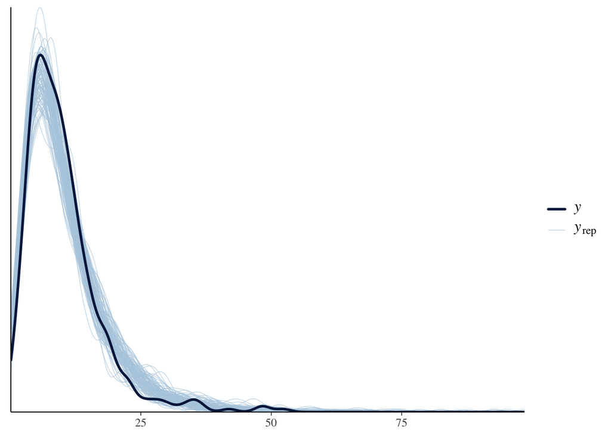

```r
pp_check(mdl_se_gamma_trunc, ndraws = 100)
```

### 2.3.2 Average predictions

Extract some effects of interest using marginaleffects and plot results.

```r
avg_predictions(mdl_se_gamma_trunc, by = "cndtn", type = "link")
```

```
##
##     cndtn Estimate 2.5 % 97.5 %
##  Baseline     2.32  2.24   2.40
##  Music A      2.17  2.04   2.30
##  Music B      2.22  2.10   2.35
##  Silence      2.16  2.05   2.29
##
## Columns: cndtn, estimate, conf.low, conf.high
## Type:  link
```

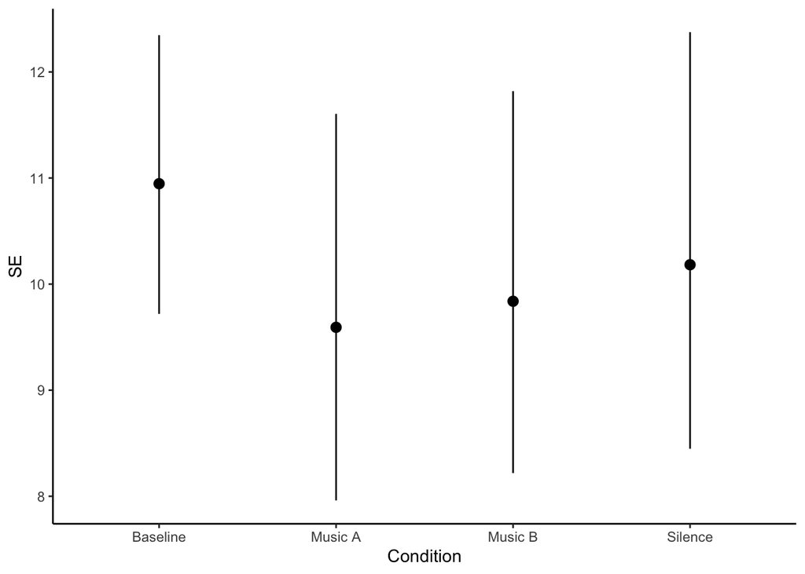

```r
plot_predictions(mdl_se_gamma_trunc, by = "cndtn", type = "prediction") +
  labs(x = 'Condition', y = 'SE') +
  theme_classic()
```

### 2.3.3 Pairwise comparisons

Look at pairwise comparisons.

```r
avg_comparisons(mdl_se_gamma_trunc, variables = list(cndtn = "pairwise"), type = "link"
) |>
  print() |>
  posterior_draws(shape = "DxP") |>
  hypothesis(c("b1 > 0",
               "b2 > 0",
               "b3 > 0",
               "b4 < 0",
               "b5 < 0",
               "b6 > 0"))
```

```
##
##   Term                       Contrast Estimate  2.5 % 97.5 %
##  cndtn mean(Music A) - mean(Baseline)  -0.1799 -0.369 0.0116
##  cndtn mean(Music B) - mean(Baseline)  -0.0830 -0.237 0.0666
##  cndtn mean(Silence) - mean(Baseline)  -0.1226 -0.278 0.0397
##  cndtn mean(Music B) - mean(Music A)    0.0949 -0.119 0.3103
##  cndtn mean(Silence) - mean(Music A)    0.0584 -0.151 0.2772
##  cndtn mean(Silence) - mean(Music B)   -0.0368 -0.213 0.1527
##
## Columns: term, contrast, estimate, conf.low, conf.high, predicted_lo, predicted_hi, predicted, tmp_idx
## Type:  link
```

```
## Hypothesis Tests for class :
##   Hypothesis Estimate Est.Error CI.Lower CI.Upper Evid.Ratio Post.Prob Star
## 1   (b1) > 0    -0.18      0.10    -0.34    -0.02       0.04      0.03
## 2   (b2) > 0    -0.08      0.08    -0.22     0.04       0.16      0.14
## 3   (b3) > 0    -0.12      0.08    -0.25     0.01       0.07      0.07
## 4   (b4) < 0     0.10      0.11    -0.08     0.27       0.22      0.18
## 5   (b5) < 0     0.06      0.11    -0.12     0.24       0.42      0.30
## 6   (b6) > 0    -0.04      0.09    -0.19     0.12       0.55      0.36
## ---
## 'CI': 90%-CI for one-sided and 95%-CI for two-sided hypotheses.
## '*': For one-sided hypotheses, the posterior probability exceeds 95%;
## for two-sided hypotheses, the value tested against lies outside the 95%-CI.
## Posterior probabilities of point hypotheses assume equal prior probabilities.
```

# 3 Preference comparisons

Let’s look at the balance of preference. The main df pref column is repeated for each participant across all their nights, so we need to condense this down to the unique response per participant.

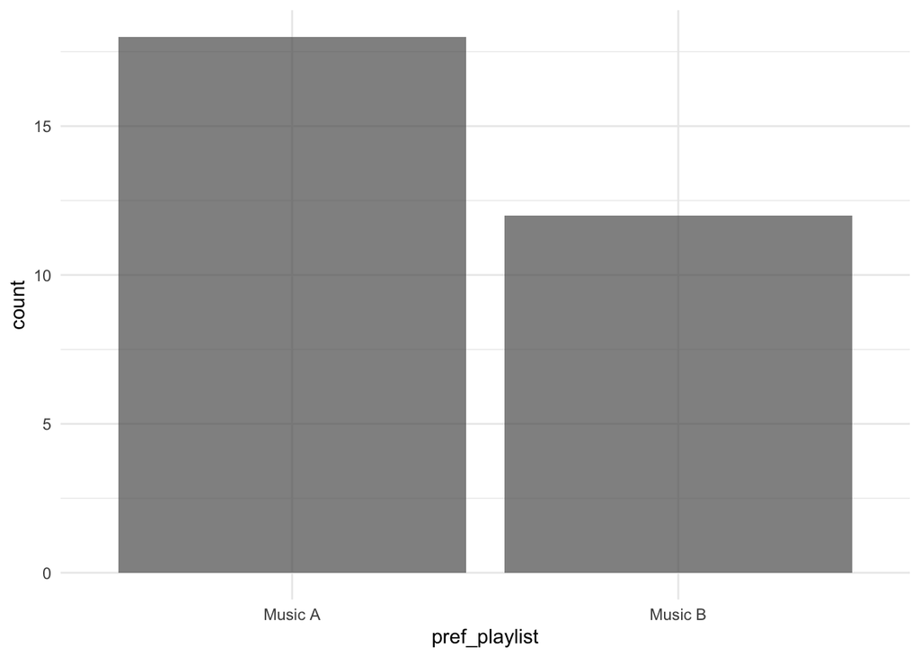

```r
pref_playlist_df <- unique(data_sleep[,c('ID','pref_playlist')])

ggplot(pref_playlist_df, aes(pref_playlist)) +
  geom_histogram(stat = 'count', alpha = 0.7) +
  theme_minimal()
```

We can see that more participants preferred Music A than Music B, but not by a large margin; more than one third of participants preferred Music B.

## 3.1 SQ

### 3.1.1 Model fit

```r
mdl_sq_pref <-
  brm(
    sleep_qual ~
      cndtn_pref * (alertness + tension + valence) +
      (cndtn_pref | ID),
    data = data_sleep,
    family = cumulative(link = "probit"),
    prior = set_prior("normal(0, 1)", class = "b"),
    control = list(adapt_delta = 0.99)
    )
```

```
## Trying to compile a simple C file
```

[output not shown]

Posterior predictions check.

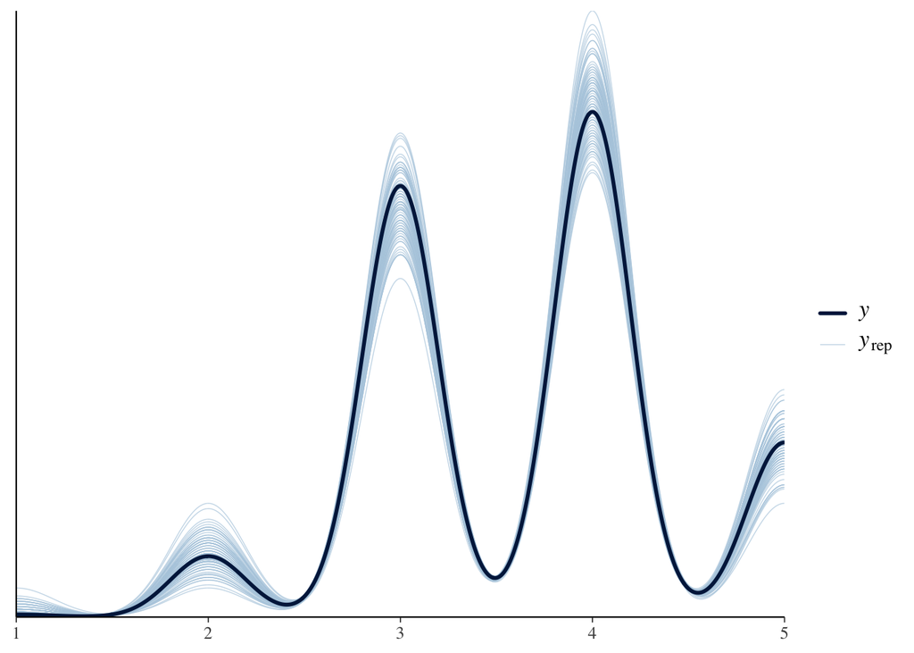

```r
pp_check(mdl_sq_pref, ndraws = 100)
```

### 3.1.2 Average predictions

Extract some effects of interest using marginaleffects and plot results.

```r
avg_predictions(mdl_sq_pref, by = "cndtn_pref", type = "link")
```

```
##
##  cndtn_pref Estimate 2.5 % 97.5 %
##    Baseline    0.697 0.186   1.21
##    Not pref    0.731 0.139   1.32
##    Pref        1.287 0.708   1.88
##    Silence     0.840 0.269   1.45
##
## Columns: cndtn_pref, estimate, conf.low, conf.high
## Type:  link
```

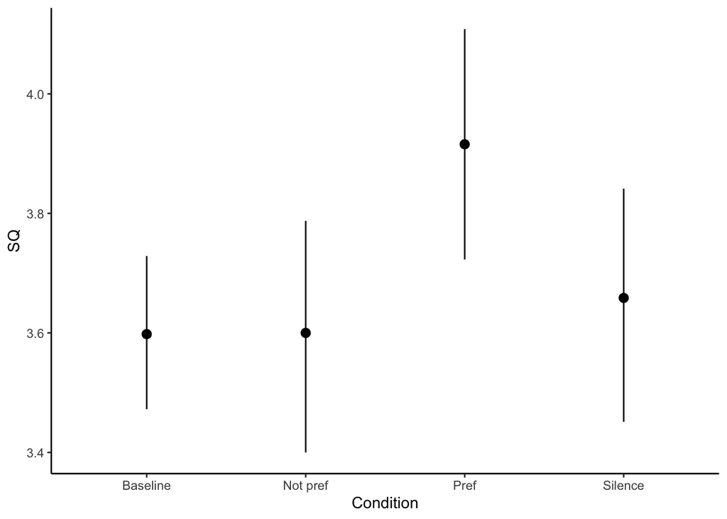

```r
plot_predictions(mdl_sq_pref, by = "cndtn_pref", type = "prediction") +
  labs(x = 'Condition', y = 'SQ') +
  theme_classic()
```

### 3.1.3 Pairwise comparisons

Look at pairwise comparisons.

```r
avg_comparisons(mdl_sq_pref, variables = list(cndtn_pref = "pairwise"), type = "link") |>
  print() |>
  posterior_draws(shape = "DxP") |>
  hypothesis(c("b1 > 0",
               "b2 > 0",
               "b3 > 0",
               "b4 < 0",
               "b5 < 0",
               "b6 > 0"))
```

```
##
##        Term                        Contrast Estimate   2.5 %  97.5 %
##  cndtn_pref mean(Not pref) - mean(Baseline)   0.0676 -0.2536  0.3795
##  cndtn_pref mean(Pref) - mean(Baseline)       0.5025  0.2096  0.8237
##  cndtn_pref mean(Silence) - mean(Baseline)    0.0776 -0.2209  0.3892
##  cndtn_pref mean(Pref) - mean(Not pref)       0.4422  0.0487  0.8086
##  cndtn_pref mean(Silence) - mean(Not pref)    0.0192 -0.3713  0.3956
##  cndtn_pref mean(Silence) - mean(Pref)       -0.4223 -0.7946 -0.0475
##
## Columns: term, contrast, estimate, conf.low, conf.high, predicted_lo, predicted_hi, predicted, tmp_idx
## Type:  link
```

```
## Hypothesis Tests for class :
##   Hypothesis Estimate Est.Error CI.Lower CI.Upper Evid.Ratio Post.Prob Star
## 1   (b1) > 0     0.07      0.16    -0.20     0.33       1.98      0.66
## 2   (b2) > 0     0.51      0.16     0.25     0.77    1332.33      1.00    *
## 3   (b3) > 0     0.08      0.16    -0.17     0.34       2.25      0.69
## 4   (b4) < 0     0.44      0.20     0.12     0.76       0.01      0.01
## 5   (b5) < 0     0.01      0.20    -0.31     0.33       0.87      0.47
## 6   (b6) > 0    -0.43      0.19    -0.74    -0.11       0.01      0.01
## ---
## 'CI': 90%-CI for one-sided and 95%-CI for two-sided hypotheses.
## '*': For one-sided hypotheses, the posterior probability exceeds 95%;
## for two-sided hypotheses, the value tested against lies outside the 95%-CI.
## Posterior probabilities of point hypotheses assume equal prior probabilities.
```

## 3.2 SOL

### 3.2.1 Model fit

```r
mdl_solpref_gamma <-
  brm(
    sleep_onset_add1 ~
      cndtn_pref * (alertness + tension + valence) +
      (cndtn | ID),
    data = data_sleep,
    family = "gamma",
    prior = set_prior("normal(0, 1)", class = "b"),
    control = list(adapt_delta = 0.99)
    )
```

```
## Trying to compile a simple C file
```

[output not shown]

Posterior predictions check.

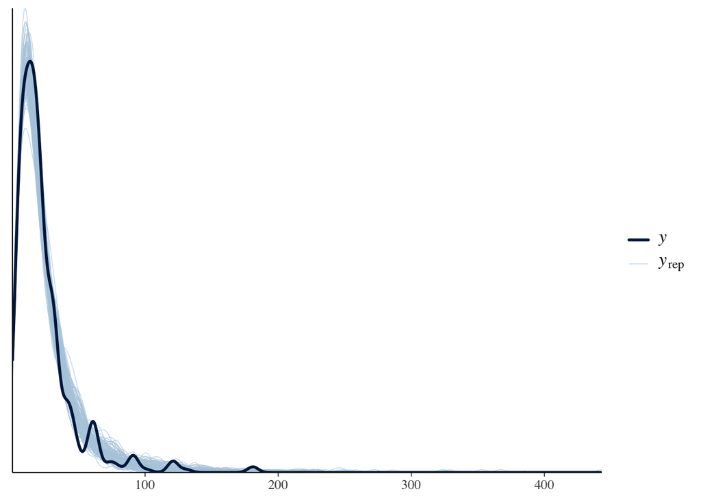

```r
pp_check(mdl_solpref_gamma, ndraws = 100)
```

### 3.2.2 Average predictions

Extract some effects of interest using marginaleffects and plot results.

```r
avg_predictions(mdl_solpref_gamma, by = "cndtn_pref", type = "link")
```

```
##
##  cndtn_pref Estimate 2.5 % 97.5 %
##    Baseline     3.01  2.93   3.08
##    Not pref     3.10  2.99   3.22
##    Pref         2.83  2.72   2.95
##    Silence      2.96  2.84   3.08
##
## Columns: cndtn_pref, estimate, conf.low, conf.high
## Type:  link
```

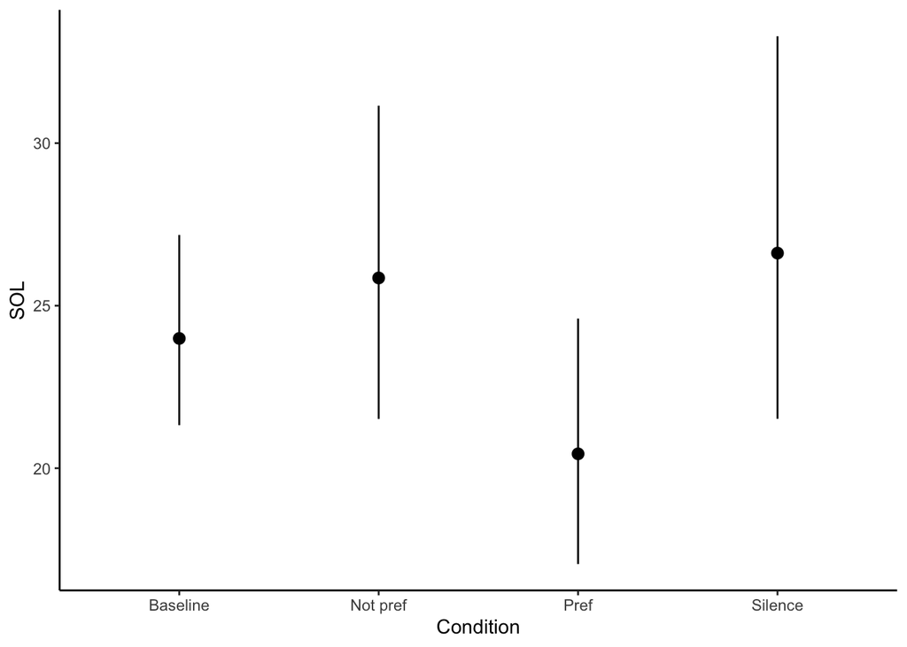

```r
plot_predictions(mdl_solpref_gamma, by = "cndtn_pref", type = "prediction") +
  labs(x = 'Condition', y = 'SOL') +
  theme_classic()
```

### 3.2.3 Pairwise comparisons

Look at pairwise comparisons.

```r
avg_comparisons(mdl_solpref_gamma, variables = list(cndtn_pref = "pairwise"), type = "link") |>
  print() |>
  posterior_draws(shape = "DxP") |>
  hypothesis(c("b1 > 0",
               "b2 > 0",
               "b3 > 0",
               "b4 < 0",
               "b5 < 0",
               "b6 > 0"))
```

```
##
##        Term                        Contrast Estimate   2.5 % 97.5 %
##  cndtn_pref mean(Not pref) - mean(Baseline)   0.1079 -0.0938 0.3078
##  cndtn_pref mean(Pref) - mean(Baseline)      -0.1277 -0.3344 0.0786
##  cndtn_pref mean(Silence) - mean(Baseline)    0.0162 -0.1764 0.2031
##  cndtn_pref mean(Pref) - mean(Not pref)      -0.2353 -0.4765 0.0126
##  cndtn_pref mean(Silence) - mean(Not pref)   -0.0924 -0.3433 0.1538
##  cndtn_pref mean(Silence) - mean(Pref)        0.1414 -0.1027 0.3893
##
## Columns: term, contrast, estimate, conf.low, conf.high, predicted_lo, predicted_hi, predicted, tmp_idx
## Type:  link
```

```
## Hypothesis Tests for class :
##   Hypothesis Estimate Est.Error CI.Lower CI.Upper Evid.Ratio Post.Prob Star
## 1   (b1) > 0     0.11      0.10    -0.06     0.27       6.26      0.86
## 2   (b2) > 0    -0.13      0.11    -0.30     0.04       0.12      0.11
## 3   (b3) > 0     0.02      0.10    -0.14     0.17       1.32      0.57
## 4   (b4) < 0    -0.23      0.13    -0.44    -0.03      34.09      0.97    *
## 5   (b5) < 0    -0.09      0.13    -0.30     0.11       3.31      0.77
## 6   (b6) > 0     0.14      0.13    -0.07     0.35       6.77      0.87
## ---
## 'CI': 90%-CI for one-sided and 95%-CI for two-sided hypotheses.
## '*': For one-sided hypotheses, the posterior probability exceeds 95%;
## for two-sided hypotheses, the value tested against lies outside the 95%-CI.
## Posterior probabilities of point hypotheses assume equal prior probabilities.
```

## 3.3 SE

### 3.3.1 Model fit

```r
mdl_sepref_gamma_trunc <-
  brm(
    sleep_effncy_inv | trunc(ub = 100) ~
      cndtn_pref * (alertness + tension + valence) +
      (cndtn | ID),
    data = data_sleep,
    family = "gamma",
    prior = set_prior("normal(0, 1)", class = "b"),
    control = list(adapt_delta = 0.99)
    )
```

```
## Trying to compile a simple C file
```

[output not shown]

Posterior predictions check.

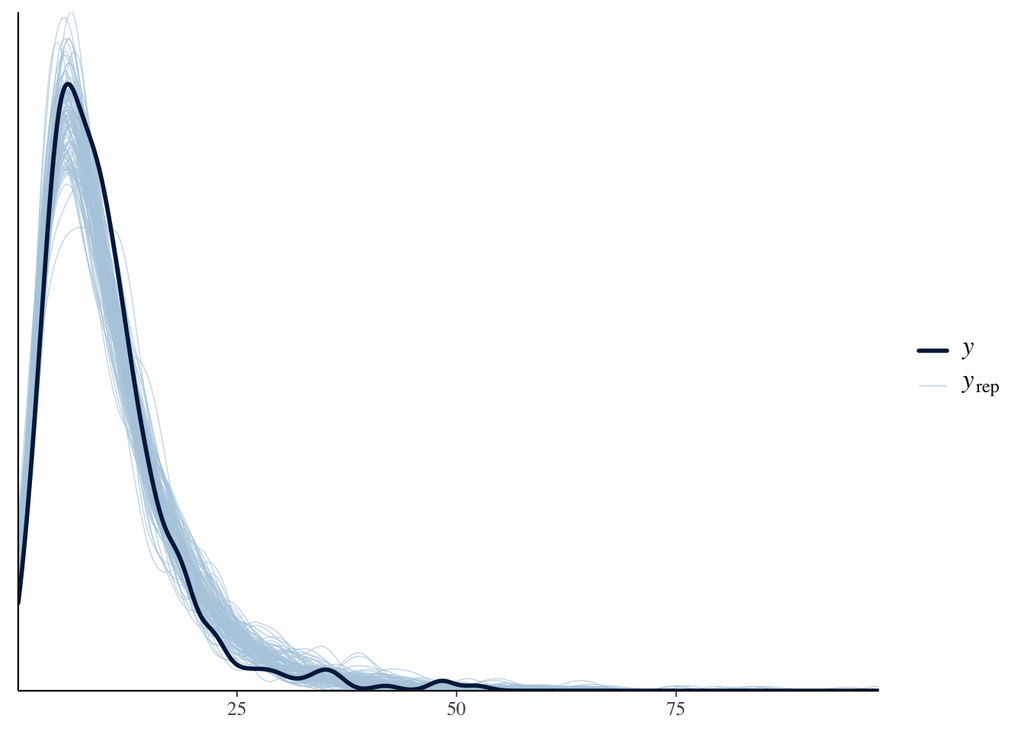

```r
pp_check(mdl_sepref_gamma_trunc, ndraws = 100)
```

### 3.3.2 Average predictions

Extract some effects of interest using marginaleffects and plot results.

```r
avg_predictions(mdl_sepref_gamma_trunc, by = "cndtn_pref", type = "link")
```

```
##
##  cndtn_pref Estimate 2.5 % 97.5 %
##    Baseline     2.32  2.24   2.40
##    Not pref     2.34  2.22   2.46
##    Pref         2.05  1.93   2.18
##    Silence      2.16  2.04   2.29
##
## Columns: cndtn_pref, estimate, conf.low, conf.high
## Type:  link
```

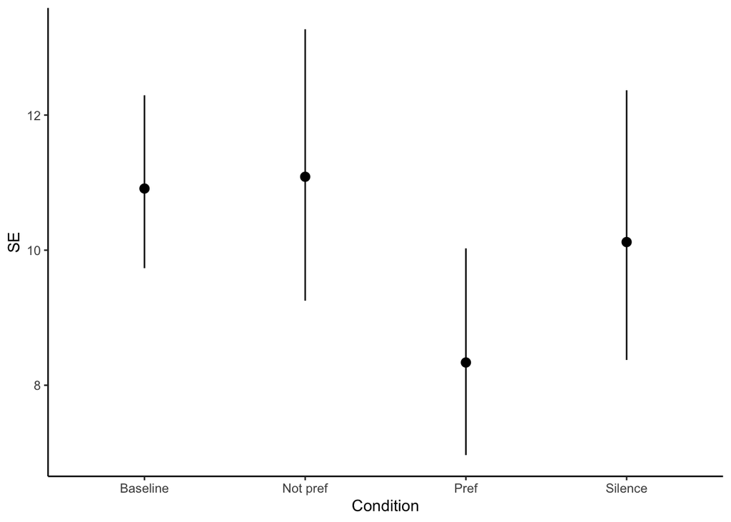

```r
plot_predictions(mdl_sepref_gamma_trunc, by = "cndtn_pref", type = "prediction") +
  labs(x = 'Condition', y = 'SE') +
  theme_classic()
```

### 3.3.3 Pairwise comparisons

Look at pairwise comparisons.

```r
avg_comparisons(mdl_sepref_gamma_trunc, variables = list(cndtn_pref = "pairwise"), type = "link") |>
  print() |>
  posterior_draws(shape = "DxP") |>
  hypothesis(c("b1 > 0",
               "b2 > 0",
               "b3 > 0",
               "b4 < 0",
               "b5 < 0",
               "b6 > 0"))
```

```
##
##        Term                        Contrast Estimate   2.5 %  97.5 %
##  cndtn_pref mean(Not pref) - mean(Baseline)  0.00892 -0.1595  0.1828
##  cndtn_pref mean(Pref) - mean(Baseline)     -0.27160 -0.4544 -0.0979
##  cndtn_pref mean(Silence) - mean(Baseline)  -0.12142 -0.2940  0.0618
##  cndtn_pref mean(Pref) - mean(Not pref)     -0.28034 -0.4925 -0.0706
##  cndtn_pref mean(Silence) - mean(Not pref)  -0.13291 -0.3512  0.0911
##  cndtn_pref mean(Silence) - mean(Pref)       0.15000 -0.0732  0.3887
##
## Columns: term, contrast, estimate, conf.low, conf.high, predicted_lo, predicted_hi, predicted, tmp_idx
## Type:  link
```

```
## Hypothesis Tests for class :
##   Hypothesis Estimate Est.Error CI.Lower CI.Upper Evid.Ratio Post.Prob Star
## 1   (b1) > 0     0.01      0.09    -0.13     0.15       1.20      0.55
## 2   (b2) > 0    -0.27      0.09    -0.43    -0.12       0.00      0.00
## 3   (b3) > 0    -0.12      0.09    -0.27     0.03       0.10      0.09
## 4   (b4) < 0    -0.28      0.11    -0.46    -0.11     152.85      0.99    *
## 5   (b5) < 0    -0.13      0.11    -0.31     0.05       7.10      0.88
## 6   (b6) > 0     0.15      0.12    -0.04     0.34       9.34      0.90
## ---
## 'CI': 90%-CI for one-sided and 95%-CI for two-sided hypotheses.
## '*': For one-sided hypotheses, the posterior probability exceeds 95%;
## for two-sided hypotheses, the value tested against lies outside the 95%-CI.
## Posterior probabilities of point hypotheses assume equal prior probabilities.
```

# 4 Summary

We have found strong evidence for an effect of music on different measures of sleep behaviours. The particular playlist outright seems to have an effect on sleep quality, with Music A in this case associated with greater SQ than the other conditions. However, there was no evidence for an effect on the other measures of sleep.

There was no strong evidence for music preference having an effect compared to no music for SOL and SE, however there was evidence of an effect of preference between the two playlists. This may still highlight a role of preference that is relevant for listening to music to go to sleep. There was a trend towards improved SOL and SE when listening to music that is preferred, and to a lesser extent in the opposite direction for music that is not. Although there was no strong evidence for either difference compared to Silence, this could still indicate preference as an important factor for choosing music for sleep.

Overall, there is indication that certain types of music can improve sleep quality. Preference for that music may further impact other measures of sleep behaviours.